# Анализ сетей книг

Чеснокова Елена, eyuchesnokova

## Исследовательские вопросы

- Отличаются ли связи между книгами по разным “полкам”?
- Есть ли связь между схожестью комиксов и средним рейтингом?

Сформулировав исследовательские вопросы, возьмём те характеристики книг, которые нам могут понадобиться в ходе анализа и поиска ответов.

Для начала выделим группу из данной сети, для которой будет проведён анализ. В работе будут учтены только те книги (вершины), год публикации которых не меньше, чем 2014, так как таким образом мы учтём самые новые комиксы. Данная группа была выделена, чтобы последующий анализ был наиболее актульным и применим для комиксов, которые будут выпущены в ближайшие годы.

## Выявление значимых вершин

Для того, чтобы определить, насколько значима та или иная вершина, возьмём меру degree (степень), которая показывает, сколько связей имеет вершина. Таким образом самыми важными вершинами будут те, у которых связей будет больше всего.

```
##    n
## 1 16
```

| Title | degree |
| --- | --- |
| Re-Gifters | 23 |
| Vader (Star Wars: Darth Vader #1) | 22 |
| Ms. Marvel, Vol. 6: Civil War II | 22 |
| The Unbeatable Squirrel Girl, Volume 1: Squirrel Power | 22 |
| Death Note, Vol. 12: Finis (Death Note, #12) | 18 |
| Flashpoint | 18 |
| The Doll’s House (The Sandman #2) | 17 |
| The Walking Dead, Vol. 05: The Best Defense | 16 |
| Preacher, Volume 2: Until the End of the World | 16 |
| Lumberjanes #2 | 15 |

**Использованные меры центральности: betweenness, degree, eigenvector centrality**

Также, чтобы определить значимость комиксов, используем центральность по посредничеству, которая отвечает за “выгодное” расположение вершины, то есть за долю кратчайших путей, проходящих через данную вершину.

| Title | betweenness |
| --- | --- |
| Vader (Star Wars: Darth Vader #1) | 2947.8232 |
| Ms. Marvel, Vol. 6: Civil War II | 2104.0240 |
| The Unbeatable Squirrel Girl, Volume 1: Squirrel Power | 1085.3012 |
| The Walking Dead, Vol. 04: The Heart’s Desire | 1062.2227 |
| Re-Gifters | 898.2841 |
| Seconds | 858.3687 |
| Brain Camp | 809.5642 |
| Queen and Country: The Definitive Edition, Vol. 1 | 746.0000 |
| Marvels | 744.4033 |
| Calamity Jack (Rapunzel’s Revenge, #2) | 744.4033 |

| Title | evcent_centrality |
| --- | --- |
| Vader (Star Wars: Darth Vader #1) | 1.0000000 |
| Flashpoint | 0.9859004 |
| The Walking Dead, Vol. 05: The Best Defense | 0.9527691 |
| Lumberjanes #2 | 0.8920355 |
| Preacher, Volume 4: Ancient History | 0.8920355 |
| Re-Gifters | 0.8663042 |
| The Doll’s House (The Sandman #2) | 0.8199481 |
| Lost Girls (Lost Girls, #1-3) | 0.7870345 |
| Preacher, Volume 2: Until the End of the World | 0.7819802 |
| Preacher, Volume 3: Proud Americans | 0.7295507 |

```
## Preacher, Volume 2: Until the End of the World
##                                             16
```

```
## Preacher, Volume 2: Until the End of the World
##                                       188.8217
```

Далее оценим такой показатель как ассортативность, который отображает меру склонности узлов иметь связи с узлами,у которых сходные свойства. Таким образом мы сможем узнать, есть ли связь между сетью и интересующей нас характеритсикой. Сперва оценим данный параметр по жанрам (“полкам”), к которому относится комикс.

```
## [1] -0.01429534
```

Ассортативность показывает довольно маленькое значение, из чего следует, что схожесть комиксов не связана с его жанром, то есть похожие комиксы не обязательно имеют тот же или противоположный жанр. В данном случае наш параметр показывает отрицательное значение, таким образом похожие книги чащк имеют противоположные жанры, чем схожие. Однако число слишком маленькое, чтобы констатировать связь между сетью и данной характеристикой.

```
## [1] 0.02674763
```

```
##          5%         95%
## -0.07210307  0.06652219
```

```
## [1] 0.02674763
```

#### Визуализация

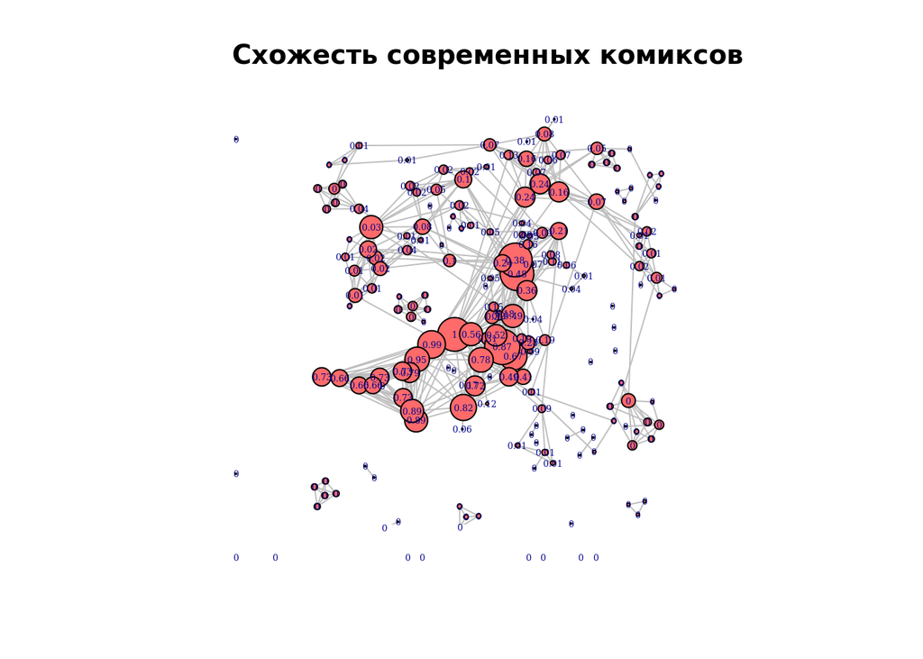

На данном графе изображены все комиксы, которые входят в анализ (то есть комиксы с годом публикации 2014 и позже). Размер вершин в этом случае показывает количество книг, с которыми данная схожа. Также здесь легко заметить те комиксы, которые не похожи ни нам какие другие (на графе они не имеют связей). Таким образом благодоря этому на графе видна структура анализируемых данных. Более того, на каждой вершине отмечено значение степени влиятельности комиксов. Несмотря на то, что сложно разобрать на графе данную метрику, можно заметить, что у некоторых вершин с большой степенью узла не очень высокая степень влиятельности.

Далее возьмём самые важные книги и сравним их центральность по посрелничеству.

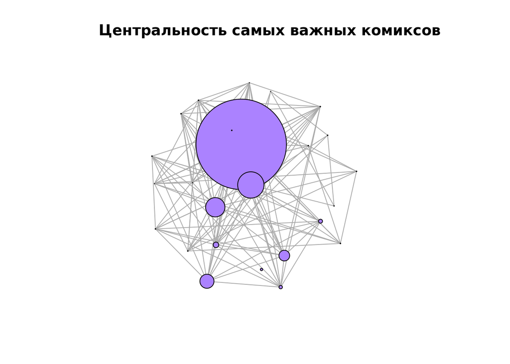

Граф показывает нам большие различия у важных комиксов в таком параметре как betweenness, что означает, что для данной сети иметь много связей не означает быть на “выгодном месте”.

#### Выводы

С помщью таких метрик как степень и центральность по посредничеству были выявлены самые важные комиксы после 2013 года: Re-Gifters, Vader, Ms. Marvel, The Unbeatable Squirrel Girl, The Walking Dead и др. К этим книгам легче всего найти аналог. Также с помощью степени влиятельности были ещё найдены комиксы, которые можно считать важными: Lumberjanes #2, Preacher. Эти книги можно назвать влиятельными, так как через них легче всего найти любой комикс.

Проаализировав связь между сетью и рейтингом и разными "полками, использовав, ассортативность, связи не было выявлено, так как значения очень маленькие.

Из визуализации результатов следует, что важные комиксы, выявленные по одному критерию, не обязательно будут важны по другому. Данный вывод сделан для книг, год публикации которых 2014 и позже.

## Выявление групп книг

Теперь разделим данные о книгах на сообщества с помощью метода Walktrap, который делит сеть на основе случайных путей, и исследуем изучаемые характеристики в разрезе сообществ. Ниже представлена таблица, в которой посчитан средний рейтинг в каждой группе и число связей, которое имеет та или иная группа. Также ниже посчитана модулярность разбиения, которая показывает качество того, как распределились сообщества. Модулярность довольно высокая, поэтому можно считать, что перед нами хорошее разбиения на группы.

**Использованные меры выделения сообществ: Walktrap**

```
## [1] 0.6907408
```

| group | mean_rating | number_of_comics |
| --- | --- | --- |
| 1 | 4.13 | 21 |
| 2 | 4.05 | 10 |
| 3 | 4.13 | 10 |
| 4 | 4.07 | 12 |
| 5 | 4.08 | 25 |
| 8 | 4.14 | 15 |
| 18 | 4.14 | 12 |
| 19 | 4.26 | 7 |

#### Визуализация

Чтобы можно было зрительно оценить граф, уберём комиксы, которые имеют мало общего с другими и сделаем ещё раз разбиение на сообщества. Также были проведёны подсчёты некоторых показателей для сети и рейтинга, результаты которых представлены в таблице ниже.

[interactive chart not shown]

| group | standard_deviation | mean_rating | number_of_comics | betweenness |
| --- | --- | --- | --- | --- |
| 6 | 0.31 | 4.17 | 13 | 95.34 |
| 5 | 0.28 | 4.04 | 19 | 63.57 |
| 2 | 0.26 | 4.13 | 10 | 2.70 |
| 8 | 0.25 | 4.26 | 7 | 0.86 |
| 1 | 0.24 | 4.09 | 9 | 41.86 |
| 7 | 0.22 | 4.07 | 7 | 43.22 |
| 4 | 0.21 | 4.15 | 19 | 109.62 |
| 3 | 0.18 | 4.03 | 13 | 113.75 |

Для каждой группы было посчитано среднеквадратическое отклонение, средний рейтинг, сумма связей и средний показатель центральности по посреднечеству. Исходя из полученных данных и графа, связи между важными сообществами и рейтингом не выявлено. То есть рейтинг комикса не зависит от того, насколько этот комикс похож на остальные, или от похожести среды (“выгодного” места в сети).

```
## [1] 0.03794508
```

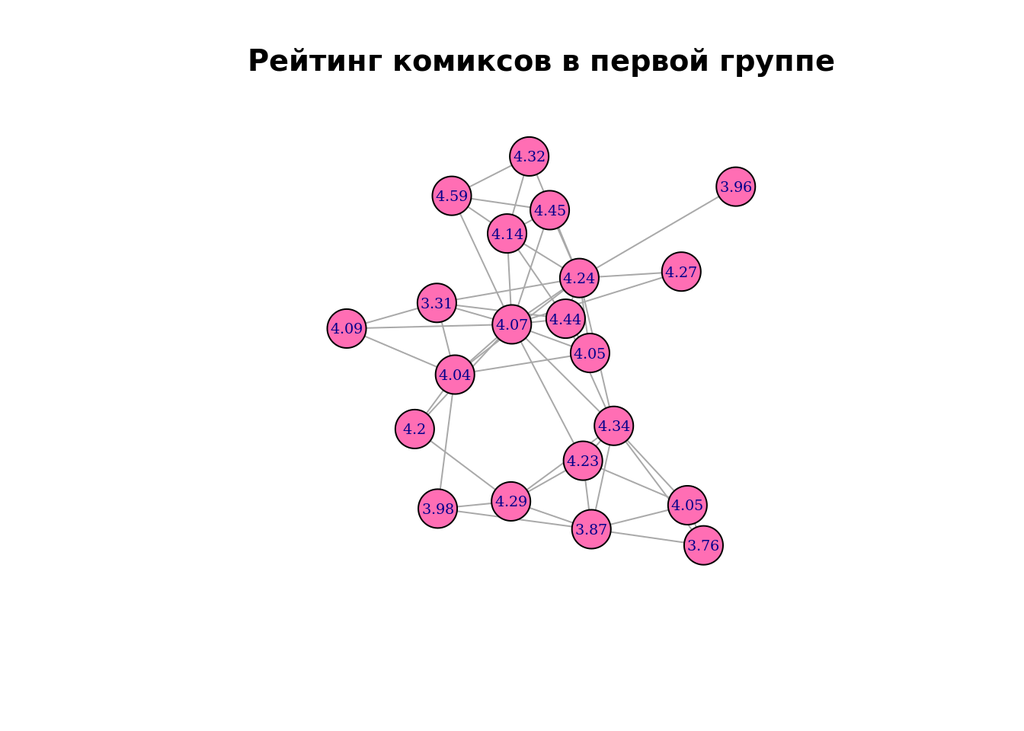

Для того,чтобы подробнее рассмотреть такую зарактеристику как рейтинг комиксов, возьмём одно сообщество из ещё не сокрашённой сети comics. Сообщество выбиралось на основе того, сколько в неём комиксов, таким оьпазом была взята почти самая большая группа (21 книги). Отсюда можно увидеть, что на графе существует тенденция того, что самые низко оценённые комикси имеют либо меньше связей (меньше похожи на другие комиксы) либо имеют не выгодное расположение (через сложнее найти остальные комиксы). Была оценена ассортативность, которая показала маленькое значение, которое говорит о том, что комиксы с одинаковым или противоположным рейтигом не похожи.

[interactive chart not shown]

#### Выводы

Разделив данные на сообщества, качество разбиения оказалось довольно высоким. Проанализировав связь по группам между сетью и исследуеымыми характеристиками, связи была выявлена не прямая. Для анализа жанров комиксов использовалась визуализация графов, то есть я посмотрела, как выглядит одна и та же сеть по факторам, которые я сравнивала. Таким образом я сделал вывод, что книги, имеющие один и тот же жанр, увеличивают свои шансы быть похожими (иметь связи в сети).

Для поиска взаимосвязи рейтинка в разных сообществам, были удалены самые неважные книги, а далее посчитаные средние значения и среднеквадратические отклонения. Таким методом я не нашла конкретной взаимосвязи между рейтингом комикса и схожестью книг по группам. Также я исследовала одно из сообществ, куда входило почти наибольшее число комиксов. Из полученного графа я сделала вывод, что чем не выгоднее позиция в сети, тем меньше рейтинг.

## Общие выводы

Исходя из полученных данных, можно сделать вывод, что комиксы, год публикации которых 2014 и позже, причисленные к одинаковой “полке”, имеют большую вероятность быть похожими. Для проверки взаимосвязи была оценена ассортативность, которая не показала взаимосвязи. Однако, основываясь на полученных графах, я сделала вывод, что такая тенденция существует.

Говоря о рейтинге комиксов, тест на ассортативность, также ничего не вявил. Для исследовании данной характеристики были рассчитаные средние значения и среднеквадратические отклоненяи для самых важных групп книг. Однако из полученных значений и графов я не смогла констатировать какую - либо взпимосвязь. Рассмотрев отдельную группу и исследовав её на данную характиристику, я сделала вывод, что чем ниже рейтинг у комикса, тем меньше комиксов можно будет найти (например, по рекомендациям) или дольше.

Более того, изучив важные комиксы, я пришла к тому, что в данном спектре книг комикс, который имеет высокую схожесть с остальными (высокую degree) не всегда является также и влиятельным (если книга влиятельная, то через неё легче и быстрее найти другие книги, даже если они совсем не похожи).

Для выбранной группы я нашла самые важные комиксы: Re-Gifters, Vader, Ms. Marvel, The Unbeatable Squirrel Girl, The Walking Dead, Lumberjanes #2, Preacher.